# Quantum Computing for Quantum Chemistry

### Student Number: 1822054

### Candidate Number: 1101066

#### March 2026

This laboratory follows the Quantum Computing for Quantum Chemistry manual [1].

Import libraries

```python
import numpy as np
from pyscf import gto
from openfermion import FermionOperator as FO
from pyscf import scf, fci
from IPython.display import Image
from openfermionpyscf import run_pyscf
from openfermion import MolecularData, get_fermion_operator
from openfermion import QubitOperator as ofQubitOperator
from openfermion.transforms import jordan_wigner
from qiskit_ibm_runtime import QiskitRuntimeService
from qiskit import QuantumCircuit
from qiskit.transpiler.preset_passmanagers import generate_preset_pass_manager
from qiskit.quantum_info import Statevector
from qiskit.visualization import plot_histogram
from qiskit_ibm_runtime import SamplerV2 as Sampler
from qiskit_aer import AerSimulator
import matplotlib.pyplot as plt
from qiskit import QuantumRegister, ClassicalRegister
from qiskit.circuit.library import QFTGate
from qiskit import transpile
import time
```

# Part I

## Conventional quantum chemistry

#### First-quantised Hamiltonians and wavefunctions

Under the Born-Oppenheimer approximation (fixed nuclei), the electronic Hamiltonian for $N$ electrons and $N_n$ nuclei is $$ \hat H=\hat h+\hat g+v_{nn}. $$ The one-electron (core) term is $$ \hat h=\sum_{i=1}^{N}\left(-\frac12\nabla_i^2-\sum_{A=1}^{N_n}\frac{Z_A}{|\mathbf r_i-\mathbf R_A|}\right), $$ with $\mathbf{r}_i$ spatial coordinates of the $i^{\text{th}}$ electron and $\mathbf{R}_A$ the spatial coordinates of the $A^{\text{th}}$ nucleus with atomic number $Z_A$. The two-electron repulsion is $$ \hat g=\frac12\sum_{i=1}^{N}\sum_{j\neq i}^{N}\frac{1}{|\mathbf r_i-\mathbf r_j|}, $$ and the nucleus-nucleus repulsion is the constant $$ v_{nn}=\frac12\sum_{A=1}^{N_n}\sum_{B\neq A}^{N_n}\frac{Z_AZ_B}{|\mathbf R_A-\mathbf R_B|}. $$ The electronic Schrödinger equation is solved, $$ \hat H\Psi_j = E_j\Psi_j\quad j=0,1,2,\dots, $$ where $\Psi_j(\mathbf x_1,\dots,\mathbf x_N)$ is an $N$-electron wavefunction with $\mathbf x_i=(\mathbf r_i,s_i)$ denoting the spatial and spin coordinates of electron $i$ [1].

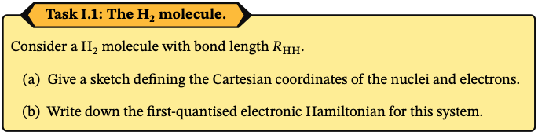

```python
Image('1_1.png')
```

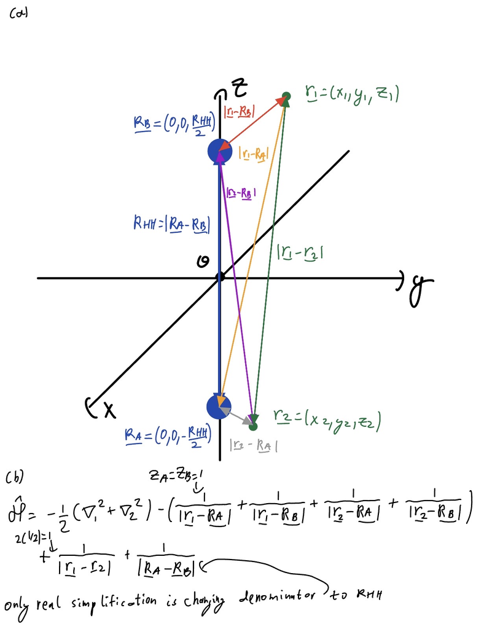

```python
Image('1_1_a.jpg')
```

#### Introducing an atomic-orbital basis set

The coordinate representation of $\hat H$ and $\Psi$ is typically replaced by a basis-set representation to enable standard linear-algebra methods. For molecules, an atomic-orbital (AO) Gaussian basis $\{\phi_\mu(\mathbf r)\}$ is used, with each function centred on a nucleus.

The one-electron operator is represented by the core Hamiltonian matrix $h$ with elements $$ h_{\mu\nu}=\int \phi_\mu^*(\mathbf r)\hat h_1(\mathbf r)\phi_\nu(\mathbf r)d\mathbf r \equiv \langle \mu|\hat h_1|\nu\rangle_{\mathbf r}. \tag{1} $$ The two-electron operator is represented by the electron repulsion integral (ERI) tensor $g$ with elements $$ g_{\mu\nu\mu'\nu'} =\iint \phi_\mu^*(\mathbf r_1)\phi_\nu^*(\mathbf r_2)\hat g_{12}(\mathbf r_1,\mathbf r_2)\phi_{\mu'}(\mathbf r_1)\phi_{\nu'}(\mathbf r_2)d\mathbf r_1d\mathbf r_2 \equiv (\mu\mu'|\nu\nu')_{\mathbf r_1\mathbf r_2}, \tag{2} $$ with $\hat g_{12}(\mathbf r_1,\mathbf r_2)=1/r_{12}=1/|\mathbf r_1-\mathbf r_2|$, and using chemists' notation [1].

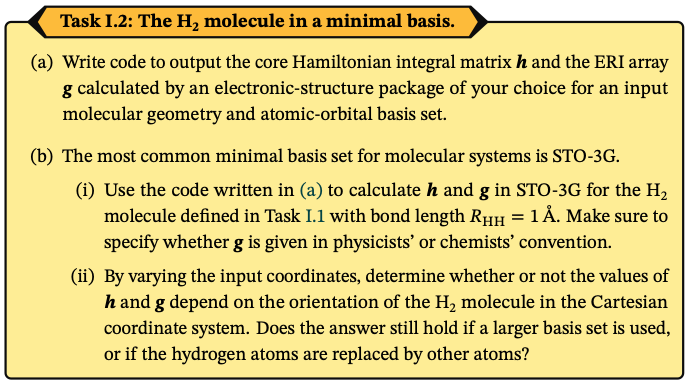

```python
Image('1_2.png')
```

**(a)**

```python
def core_and_eri(atom,basis="sto-3g",unit="Angstrom",charge= 0,spin=0):

    mol = gto.Mole()
    mol.atom = atom
    mol.unit = unit
    mol.basis = basis
    mol.charge = charge
    mol.spin = spin
    mol.build()

    # Core Hamiltonian
    h = mol.intor("int1e_kin") + mol.intor("int1e_nuc") #one electron AO integrals

    # PySCF defaults to chemists' notation
    g = mol.intor("int2e")
    v = mol.energy_nuc()#needed later
    return h,g,v
```

**(b)**

**(i)**

STO-3G is a minimal basis set where each basis function is a contracted Gaussian made from three Gaussians, fitted to approximate a Slater type orbital. In a minimal basis, one contracted function is used for each occupied atomic orbital of the free atom [2]. For $H$, the basis used here contains only $s-$type functions on each atom, so each $H$ contributes a single contracted $1s$ basis function.

PySCF has $g_{\mu\mu'\nu\nu'}=(\mu\mu'|\nu\nu')$ [3].

```python
atom = """
H 0 0 0
H 0 0 1
"""
# first is H at origin, second is H at (0,0,1)

print("Chemists' convention")
h,g,v=core_and_eri(atom=atom)
print("\nh =",h)
print("g =",g)
```

```
Chemists' convention

h = [[-0.97949638 -0.68286493]
 [-0.68286493 -0.97949638]]
g = [[[[0.77460594 0.30930897]
   [0.30930897 0.47804137]]

  [[0.30930897 0.15786578]
   [0.15786578 0.30930897]]]


 [[[0.30930897 0.15786578]
   [0.15786578 0.30930897]]

  [[0.47804137 0.30930897]
   [0.30930897 0.77460594]]]]
```

One electron energy in AO $1s$ on each $H$. $$ h_{11}=( 1|\hat h|1)_\mathbf{r} =-0.9794963769 $$

Coupling between the two AOs. $$ h_{12}=( 1|\hat h|2)_\mathbf{r} =-0.6828649331 $$

Coulomb repulsion for two electrons in AO 1 (opposite spins). $$ g_{1111}=(11|11)_{\mathbf{r}_1\mathbf{r}_2}=0.7746059439 $$

Coulomb repulsion between the overlap densities. $$ g_{1212}=(12|12)_{\mathbf{r}_1\mathbf{r}_2}=0.1578657779 $$

Coulomb interaction between densities on different atoms. $$ g_{1122}=(11|22)_{\mathbf{r}_1\mathbf{r}_2}=0.4780413732 $$

Exchange interaction. $$ g_{1221}=(12|21)_{\mathbf{r}_1\mathbf{r}_2}=0.1578657779 $$

Repulsion between the density on atom 1 and the overlap density. $$ g_{1112}=(11|12)_{\mathbf{r}_1\mathbf{r}_2}=0.3093089672 $$

**(ii)**

1. Along the $z-$axis, centered at the origin.

```python
atom = """
H 0 0 -0.5
H 0 0 0.5
"""

h,g,v=core_and_eri(atom=atom)
print("h =",h)
print("g =",g)
```

```
h = [[-0.97949638 -0.68286493]
 [-0.68286493 -0.97949638]]
g = [[[[0.77460594 0.30930897]
   [0.30930897 0.47804137]]

  [[0.30930897 0.15786578]
   [0.15786578 0.30930897]]]


 [[[0.30930897 0.15786578]
   [0.15786578 0.30930897]]

  [[0.47804137 0.30930897]
   [0.30930897 0.77460594]]]]
```

Along $y-$axis, with $z=1$.

```python
atom = """
H 0 1 1
H 0 0 1
"""
h,g,v=core_and_eri(atom=atom)
print("h =",h)
print("g =",g)
```

```
h = [[-0.97949638 -0.68286493]
 [-0.68286493 -0.97949638]]
g = [[[[0.77460594 0.30930897]
   [0.30930897 0.47804137]]

  [[0.30930897 0.15786578]
   [0.15786578 0.30930897]]]


 [[[0.30930897 0.15786578]
   [0.15786578 0.30930897]]

  [[0.47804137 0.30930897]
   [0.30930897 0.77460594]]]]
```

At $45$ degrees in the $xy-$plane.

```python
atom = """
H -0.353553 -0.353553 0
H  0.353553  0.353553 0
"""
h,g,v=core_and_eri(atom=atom)
print("h =",h)
print("g =",g)
```

```
h = [[-0.97949687 -0.68286598]
 [-0.68286598 -0.97949687]]
g = [[[[0.77460594 0.30930948]
   [0.30930948 0.47804173]]

  [[0.30930948 0.15786624]
   [0.15786624 0.30930948]]]


 [[[0.30930948 0.15786624]
   [0.15786624 0.30930948]]

  [[0.47804173 0.30930948]
   [0.30930948 0.77460594]]]]
```

Small differences due to numerical roundoff.

Along $(1,1,1)$ direction

```python
atom = """
H -0.288675 -0.288675 -0.288675
H  0.288675  0.288675  0.288675
"""
h,g,v=core_and_eri(atom=atom)
print("h =",h)
print("g =",g)
```

```
h = [[-0.97949659 -0.68286537]
 [-0.68286537 -0.97949659]]
g = [[[[0.77460594 0.30930918]
   [0.30930918 0.47804153]]

  [[0.30930918 0.15786597]
   [0.15786597 0.30930918]]]


 [[[0.30930918 0.15786597]
   [0.15786597 0.30930918]]

  [[0.47804153 0.30930918]
   [0.30930918 0.77460594]]]]
```

The electronic Hamiltonian is invariant under rigid rotations, so any observable is independent of the molecule’s absolute orientation, but the AO integral tensors $h_{pq}$ and $g_{pqrs}$ are basis dependent. If the chosen AO basis **contains** $l>0$ **functions** (even if the occupied atomic orbitals are $s-$type), a rigid rotation mixes AOs within each angular momentum shell, so the rotated integrals are generally not equal elementwise, but are related by the corresponding AO rotation within each shell.

$H_2$ is invariant here because the chosen basis is effectively $s-$only, so rotation doesn’t mix AOs.

Consider $\text{Li}_2$, $\text{Li}$’s occupied orbitals have $l=0$ (including an occupied $2s$ valence orbital), and since $2s$ and $2p$ orbitals share the same exponents, the **basis** contains $l>0$ ($p$) functions [4]. Since the chosen basis includes $p$ functions, the rotation mixes ($p_x,p_y,p_z$) and changes $h,g$ elementwise. Let's verify this.

Start with the first $\text{Li}$ at the origin, and the second along the $z-$axis up to $z=1$.

```python
atom = """
Li 0 0 0
Li 0 0 1
"""
h,g,v=core_and_eri(atom=atom)
print("h shape:", h.shape)
print("g shape:", g.shape)
print("\nTop-left 5x5 block of h:")
print(h[:5, :5])

print("\nRandom g elements:")
inds = [(0,0,0,0),(0,0,1,1),(0,0,2,7)]
for i,j,k,l in inds:
    print(f"g[{i},{j},{k},{l}] = {g[i,j,k,l]:f}")
```

```
h shape: (10, 10)
g shape: (10, 10, 10, 10)

Top-left 5x5 block of h:
[[-5.99338978 -1.363622    0.          0.         -0.11716946]
 [-1.363622   -2.17419742  0.          0.         -0.42176859]
 [ 0.          0.         -1.83933536  0.          0.        ]
 [ 0.          0.          0.         -1.83933536  0.        ]
 [-0.11716946 -0.42176859  0.          0.         -2.16072041]]

Random g elements:
g[0,0,0,0] = 1.680395
g[0,0,1,1] = 0.397727
g[0,0,2,7] = 0.287511
```

At $45$ degrees in the $xy-$plane.

```python
atom = """
Li -0.353553 -0.353553 0
Li  0.353553  0.353553 0
"""
h,g,v=core_and_eri(atom=atom)
print("h shape:", h.shape)
print("g shape:", g.shape)
print("\nTop-left 5x5 block of h:")
print(h[:5, :5])

print("\nRandom g elements:")
for i,j,k,l in inds:
    print(f"g[{i},{j},{k},{l}] = {g[i,j,k,l]:f}")
```

```
h shape: (10, 10)
g shape: (10, 10, 10, 10)

Top-left 5x5 block of h:
[[-5.99339153 -1.36362239 -0.08285147 -0.08285147  0.        ]
 [-1.36362239 -2.17419775 -0.29823541 -0.29823541  0.        ]
 [-0.08285147 -0.29823541 -2.0000282  -0.16069247  0.        ]
 [-0.08285147 -0.29823541 -0.16069247 -2.0000282   0.        ]
 [ 0.          0.          0.          0.         -1.83933573]]

Random g elements:
g[0,0,0,0] = 1.680395
g[0,0,1,1] = 0.397727
g[0,0,2,7] = 0.203928
```

As expected, both are different. The size of $h$ is $10\times 10$, i.e. 10 spatial AOs in total, or 5 per $\text{Li}$. This indicates that the basis includes $p$ functions, with each $\text{Li}$ contributing one $s$ function for $1s$, one $s$ function for $2s$, and three $p$ functions ($2p_x,2p_y,2p_z$).

#### Second quantisation

For quantum-computing treatments of electronic structure, the coordinate representation is replaced by second quantisation, where the Hamiltonian and states are expressed using discrete fermionic creation and annihilation operators. This naturally enforces antisymmetry and provides a direct encoding in an occupation-number basis.

Given $M$ orthonormal spin-orbitals $\{\chi_p(\mathbf x)\}_{p=0}^{M-1}$ with $\mathbf x=(\mathbf r,s)$, an $N$-electron configuration is represented by an occupation vector $$ |\mathbf k\rangle = |k_0,k_1,\dots,k_{M-1}\rangle,\qquad k_p\in\{0,1\}. $$

The elementary fermionic operators change the occupation of a given spin-orbital, with the fermionic phase factor $\Gamma_p^\mathbf{k}=\prod_{q=0}^{p-1}\left(-1\right)^{k_q}$ [1], $$ \hat a_p^\dagger|\dots,k_p,\dots\rangle = \delta_{k_p,0}\Gamma_p^\mathbf{k}|\dots,1,\dots\rangle, $$ $$ \hat a_p|\dots,k_p,\dots\rangle = \delta_{k_p,1}\Gamma_p^\mathbf{k}|\dots,0,\dots\rangle. $$

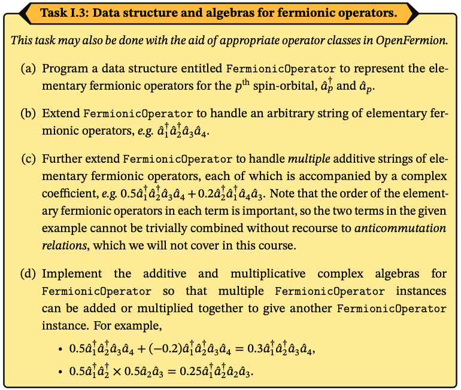

```python
Image('1_3.png')
```

```python
class FermionicOperator:
    def __init__(self, _of=None):
        self._of = _of if _of is not None else FO()
#stores operator, if empty allows zero operator

#(a)
    @staticmethod #(does not use self)
    def create(i):
        return FermionicOperator(FO(((int(i), 1),), 1.0)) #create at site i (coeff of 1)
#((int(i), 1),) is a one-element tuple holding (int(i), 1)
    @staticmethod
    def destroy(i):
        return FermionicOperator(FO(((int(i), 0),), 1.0))

#(b)
    @staticmethod
    def string(ops, coeff=1.0):
        term = tuple((int(i),ca) for i, ca in ops)
#ops is an ordered list of (i, ca), ca is create/annihilate (1 or 0 respectively)
        return FermionicOperator(FO(term, complex(coeff)))

#(c)
    @staticmethod
    def sum(terms):
        of = FO()
        for coeff, ops in terms:
            of += FermionicOperator.string(ops, coeff)._of #unwraps to get FO
        return FermionicOperator(of)
#(d)
# __add__ adds two FO objects,
    def __add__(self, other):
        return FermionicOperator(self._of + other._of)

    def __mul__(self, other):
        if isinstance(other, FermionicOperator):
# if other is a fermionic operator, do operator multiplication, otherwise do scalar multiplication
            return FermionicOperator(self._of * other._of)
        return FermionicOperator(self._of * complex(other))

    def __rmul__(self, other):
        return FermionicOperator(complex(other) * self._of)

    def __str__(self):
        #useful for II.3 part (d), prints string of object
        return str(self._of)



    def to_openfermion(self):
        return self._of
#returns operator
```

Sum and Add do the same thing in slightly different ways which is shown below, Sum reads slightly cleaner, but Add follows the task closer, so I have included both.

Verify that $0.5\hat{a}_1^\dagger\hat{a}_2^\dagger\hat{a}_3\hat{a}_4+(-0.2)\hat{a}_1^\dagger\hat{a}_2^\dagger\hat{a}_3\hat{a}_4=0.3\hat{a}_1^\dagger\hat{a}_2^\dagger\hat{a}_3\hat{a}_4$.

```python
expr1 = FermionicOperator.sum([
    (0.5, [(1,1), (2,1), (3,0), (4,0)]),
    (-0.2, [(1,1), (2,1), (3,0), (4,0)])
])
print('Using Sum, expression becomes',expr1.to_openfermion())

expr2 = (FermionicOperator.string([(1,1), (2,1), (3,0), (4,0)], 0.5)
         + FermionicOperator.string([(1,1), (2,1), (3,0), (4,0)], -0.2))
print('\nUsing Add, expression becomes',expr2.to_openfermion())
```

```
Using Sum, expression becomes (0.3+0j) [1^ 2^ 3 4]

Using Add, expression becomes (0.3+0j) [1^ 2^ 3 4]
```

Verify that $0.5\hat{a}_1^\dagger\hat{a}_2^\dagger\times0.5\hat{a}_2\hat{a}_3=0.25\hat{a}_1^\dagger\hat{a}_2^\dagger\hat{a}_2\hat{a}_3$

```python
expr3 = (FermionicOperator.string([(1,1), (2,1)], 0.5)
         * FermionicOperator.string([(2,0), (3,0)], 0.5))
print('Expression becomes',expr3.to_openfermion())
```

```
Expression becomes (0.25+0j) [1^ 2^ 2 3]
```

## Module 1 Logbook

The laboratory introduced the electronic Hamiltonian for an $N$ electron system with $N_n$ fixed nuclei, written as $\hat{\mathcal{H}}=\hat{h}+\hat{g}+v_{nn}$, where $\hat{h}$ is the one-electron term, $\hat{g}$ the two-electron interaction, and $v_{nn}$ the nucleus-nucleus repulsion. The coordinate representation was introduced first, then the Hamiltonian was expressed in an AO basis through the integrals $h_{\mu\nu}=\langle\mu|\hat{h}_1|\nu\rangle_\mathbf{r}$ and $g_{\mu\mu'\nu\nu'}=(\mu\mu'|\nu\nu')$ used in practical calculations. For $H_2$ with bond length $R_{HH}=1$ Angstrom in the STO-3G minimal basis, the core Hamiltonian integral matrix $\mathbf{h}$ and the electron repulsion integral array $\mathbf{g}$ were generated using PySCF. STO-3G is a minimal Gaussian basis set in which each basis function is formed by contracting three Gaussian primitives to approximate a Slater-type orbital. In a minimal basis, it assigns a single contracted function to each occupied atomic orbital of the isolated atom [2]. The output convention for $\mathbf{g}$ was the chemists' convention $g_{\mu\mu'\nu\nu'}=(\mu\mu'|\nu\nu')$.

Orientation tests agree with theory. For $H_2$, $\mathbf h$ and $\mathbf g$ are unchanged under rigid rotations and translations, as expected when the AO basis is effectively $s$ only. While physical observables are rotation invariant, AO integrals are only elementwise invariant when the basis contains no $l>0$ functions. Once $p$ (or higher) functions are present, a rigid rotation mixes $(p_x,p_y,p_z)$ within each atom’s shell, so $h_{pq}$ and $g_{pqrs}$ generally change elementwise, as seen in the $\text{Li}_2$ check.

Second quantisation was then introduced, treating electrons as excitations in a spin-orbital basis, which simplifies many-body problems. Instead of working with continuous coordinates, the system is described in a discrete set of spin orbitals using fermionic creation and annihilation operators. The occupation number picture makes the state space explicit, and the fermionic operator algebra automatically enforces antisymmetry. A FermionicOperator data structure was implemented to represent these creation and annihilation operators, ordered strings of operators, and sums of these strings with complex coefficients.

Correctness was checked in two ways. The additive and multiplicative examples provided in the laboratory book were reproduced, confirming that identical strings combined by coefficient addition and that multiplication produced the expected coefficient product with the operator strings concatenated in the correct order. For the integral generation, the rotation invariance test confirmed that the geometry, units, and integral calls were consistent.

# Part II

## Towards Quantum Computing

The occupation-number state $|\mathbf k\rangle$ is generated from the vacuum by [1] $$|\mathbf{k}\rangle=\left[\prod_{p=0}^{M-1} \left(\hat{a}_p^\dagger\right)^{k_p}\right]|\text{vac}\rangle=\left(\hat{a}_0^\dagger\right)^{k_0}\left(\hat{a}_1^\dagger\right)^{k_1}\cdots\left(\hat{a}_{M-1}^\dagger\right)^{k_{M-1}}|0,0,\cdots,0\rangle$$ $$ =\begin{cases}\left(\hat{a}_{M-1}^\dagger\right)^{1}|0,0,\cdots,0\rangle=|0,0,\cdots,0,1\rangle,& k_0=\cdots =k_{M-2}=0,k_{M-1}=1\\|0,0,\cdots,0\rangle,& k_0=\cdots= k_{M-1}=0.\end{cases}$$ For fermions, a fixed mode ordering is applied to avoid sign ambiguities, the product then acts on $|\text{vac}\rangle$ from right to left.

Note that until stated otherwise, the convention that the leftmost bit corresponds to qubit $0$ will be used, as in the manual.

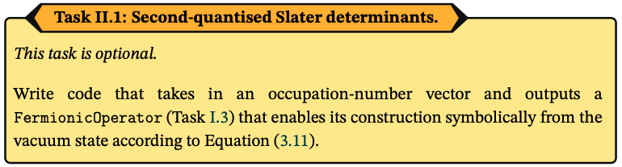

```python
Image('2_1.png')
```

```python
def occupation_to_operator(k):
    ops = [(i, 1) for i, occ in enumerate(k) if occ] #(i,1) for every occ=1
    return FermionicOperator.string(ops, 1.0)
```

```python
k1 = (1,0,1,0)
op = occupation_to_operator(k1)
print('k1 =',op.to_openfermion())


k2 = (0,1,1,0,1)
op2 = occupation_to_operator(k2)
print('k2 =',op2.to_openfermion())
```

```
k1 = (1+0j) [0^ 2^]
k2 = (1+0j) [1^ 2^ 4^]
```

The electronic Hamiltonian is written in second quantisation as $$ \hat H=\sum_{pq}^{M-1} h_{pq}\hat a_p^\dagger \hat a_q +\frac12\sum_{pqrs}^{M-1} g_{pqrs}\hat a_p^\dagger \hat a_r^\dagger \hat a_s \hat a_q +v_{nn}, $$ where the one- and two-electron integrals are $$ h_{pq}=\int \chi_p^*(\mathbf x)\hat h_1(\mathbf r)\chi_q(\mathbf x)d\mathbf x, \quad g_{pqrs}=\iint \chi_p^*(\mathbf x_1)\chi_q^*(\mathbf x_2)\hat g_{12}(\mathbf r_1,\mathbf r_2)\chi_r(\mathbf x_1)\chi_s(\mathbf x_2)d\mathbf x_1d\mathbf x_2. $$ Unlike the integrals in $(1)$ and $(2)$, these involve integration over both spatial and spin coordinates, rather than only involving spatial coordinates [1].

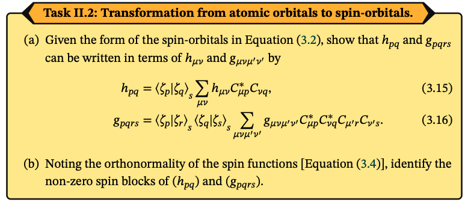

```python
Image('2_2.png')
```

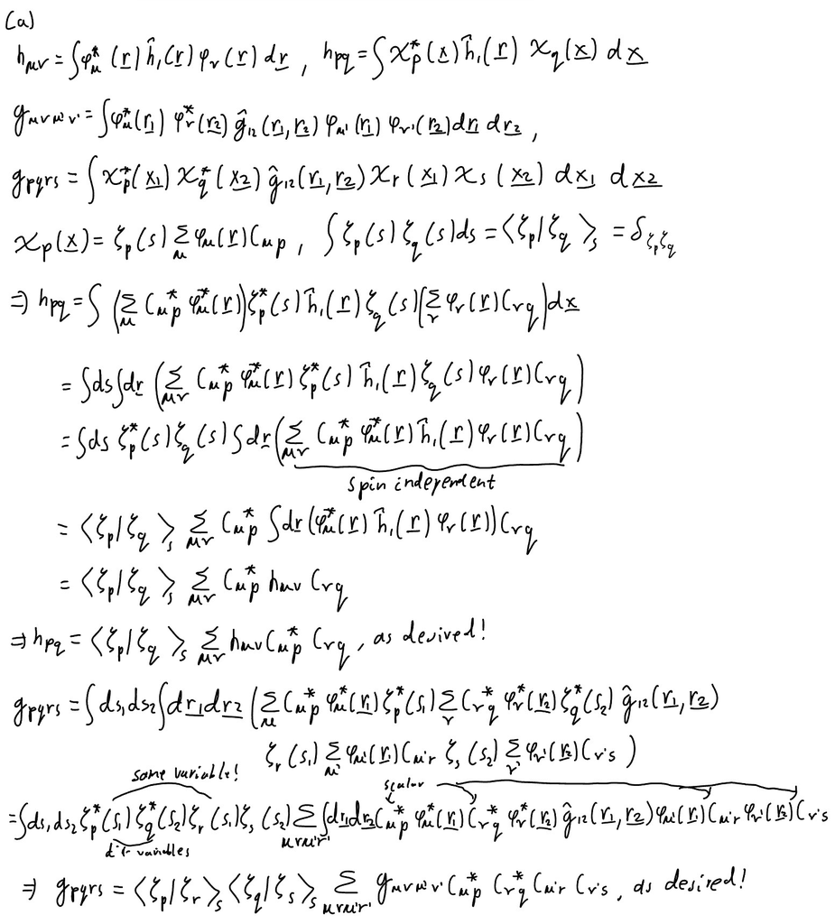

```python
Image('2_2a.jpg')
```

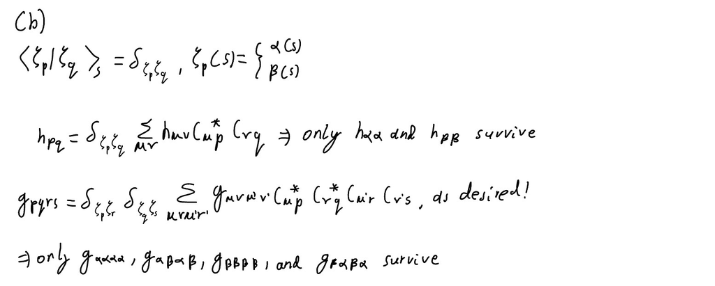

```python
Image('2_2b.jpg')
```

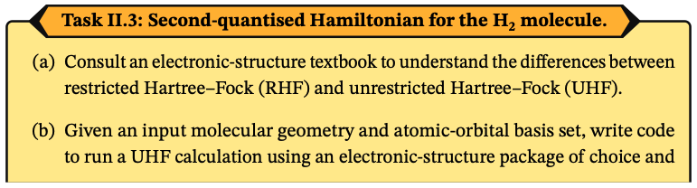

```python
Image('2_3a.png')
```

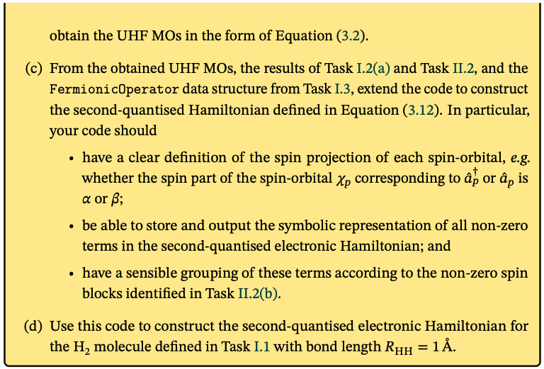

```python
Image('2_3b.png')
```

**(a)**

Restricted Hartree-Fock (RHF) uses the same spatial orbital for the $\alpha$ and $\beta$ electrons in each pair. It works best for closed-shell molecules, however since the same spatial orbital is used, it cannot describe bond breaking into open-shell molecules/atoms. E.g. $H_2$ dissociates into $H^+$ and $H^-$, rather than two $H$ atoms.

Unrestricted Hartree-Fock (UHF) uses separate spatial orbitals for $\alpha$ and $\beta$ electrons. UHF can be used for open and closed shell molecules, and usually dissociates correctly. At equilibrium geometry for closed shell molecules, RHF and UHF wavefunctions are almost identical. RHF wavefunctions are usually used for closed shells, because it is cheaper, however it shouldn't be used for closed shells that may dissociate into open shells. Separate spatial orbitals introduce 'spin contamination' error, whose size depends on the chemical system involved [2].

**(b)**

```python
def uhf_mos(atom, basis, unit="Angstrom", charge=0, spin=0):

    mol = gto.Mole()
    mol.atom = atom
    mol.unit = unit
    mol.basis = basis
    mol.charge = charge
    mol.spin = spin
    mol.build()


    mf = scf.UHF(mol)
    mf.verbose = 0 #no print
    mf.run()
    occ_alpha, occ_beta = mf.mo_occ
    E_uhf = mf.e_tot

    C_alpha, C_beta = mf.mo_coeff
    ao_labels = mol.ao_labels()
    #all of these will be useful for later sections
    return C_alpha, C_beta, ao_labels, (occ_alpha, occ_beta), E_uhf
```

**(c)**

Note 1

Noting that $\sum_{\mu\nu}h_{\mu\nu}C_{\mu p}^*C_{\nu q}=\sum_{\mu}C_{\mu p}^*\sum_{\nu}h_{\mu\nu}C_{\nu q}=\sum_{\mu}\left(C^\dagger\right)_{p\mu}\left(hC\right)_{\mu q}=\left(C^\dagger hC\right)_{pq}$

Note 2

Noting the einstein summation used to find $g_{pqrs}$.

```python
a = np.arange(16).reshape(2,2,2,2)
b = np.arange(4).reshape(2,2)
print(a)
print(b)
```

```
[[[[ 0  1]
   [ 2  3]]

  [[ 4  5]
   [ 6  7]]]


 [[[ 8  9]
   [10 11]]

  [[12 13]
   [14 15]]]]
[[0 1]
 [2 3]]
```

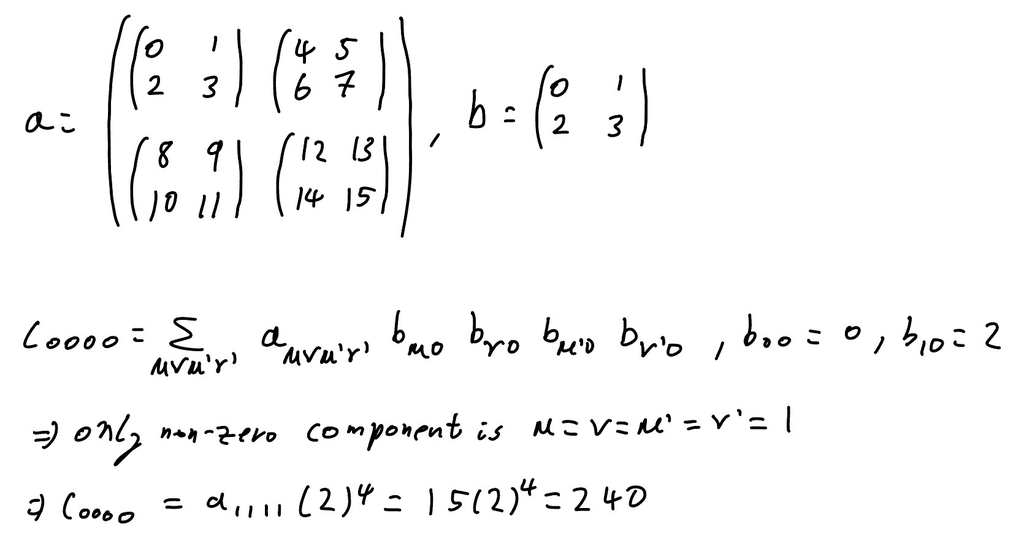

```python
Image('note_2.jpg')
```

```python
c=np.einsum('abcd,ap,bq,cr,ds->pqrs', a, b, b, b, b)
print(c)
```

```
[[[[ 240  472]
   [ 464  912]]

  [[ 448  880]
   [ 864 1696]]]


 [[[ 416  816]
   [ 800 1568]]

  [[ 768 1504]
   [1472 2880]]]]
```

$\Rightarrow g_{pqrs}=\sum_{\mu\nu\mu'\nu'}g_{\mu\nu\mu'\nu'}C^{*}_{\mu p} C^{*}_{\nu q} C_{\mu' r} C_{\nu' s}$ for the four cases identified in II.2(b).

```python
def second_quantized_hamiltonian(atom, basis, unit = "Angstrom", charge = 0, spin = 0):

    C_alpha, C_beta, ao_labels, (occ_alpha, occ_beta),E_uhf=uhf_mos(atom,basis,unit,charge, spin)
    h,g,v=core_and_eri(atom,basis,unit,charge,spin)

    # Note 1 above
    h_aa = C_alpha.conj().T @ h @ C_alpha
    h_bb = C_beta.conj().T  @ h @ C_beta

    # Note 2 above
    g_aaaa = np.einsum('abcd,ap,bq,cr,ds->pqrs', g, C_alpha.conj(), C_alpha.conj(), C_alpha, C_alpha)
    g_bbbb = np.einsum('abcd,ap,bq,cr,ds->pqrs', g, C_beta.conj(),  C_beta.conj(),  C_beta,  C_beta)
    g_abab = np.einsum('abcd,ap,bq,cr,ds->pqrs', g, C_alpha.conj(), C_beta.conj(),  C_alpha, C_beta)
    g_baba = np.einsum('abcd,ap,bq,cr,ds->pqrs', g, C_beta.conj(),  C_alpha.conj(), C_beta,  C_alpha)

    h_αα=FermionicOperator()
    h_ββ=FermionicOperator()
    g_αααα=FermionicOperator()
    g_αβαβ=FermionicOperator()
    g_βαβα=FermionicOperator()
    g_ββββ=FermionicOperator()

    nmo = h_aa.shape[0]  # number of spatial molecular orbitals

    for p in range(nmo):
        for q in range(nmo):
            #one-electron terms
            h_αα += FermionicOperator.string([(2*p, 1), (2*q, 0)], h_aa[p, q])
            # need different indexing since a_α neq a_β, have α even, β odd
            h_ββ += FermionicOperator.string([(2*p+1, 1), (2*q+1, 0)], h_bb[p, q])
            for r in range(nmo):
                for s in range(nmo):
                    #two-electron terms
                    #swap q and r as using chemist notation
                    g_αααα+=FermionicOperator.string([(2*p, 1), (2*q, 1), (2*s, 0), (2*r, 0)],g_aaaa[p,r,q,s])
                    g_αβαβ+=FermionicOperator.string([(2*p, 1), (2*q+1, 1), (2*s+1, 0), (2*r, 0)],g_abab[p,r,q,s])
                    g_βαβα+=FermionicOperator.string([(2*p+1, 1), (2*q, 1), (2*s, 0), (2*r+1, 0)],g_baba[p,r,q,s])
                    g_ββββ+=FermionicOperator.string([(2*p+1, 1), (2*q+1, 1), (2*s+1, 0), (2*r+1, 0)],g_bbbb[p,r,q,s])

    H = h_αα + h_ββ + 0.5*(g_αααα + g_αβαβ + g_βαβα + g_ββββ) + FermionicOperator.string([], v)#need constant of same form
    return H
```

**(d)**

```python
atom = """
H 0 0 0
H 0 0 1
"""
basis = "sto-3g"

H = second_quantized_hamiltonian(atom=atom, basis="sto-3g")
print(H)
```

```
(0.52917721092+0j) [] +
(-1.110844179883727+0j) [0^ 0] +
(0.3132012497647588+0j) [0^ 0^ 0 0] +
(0.09839529174273509+0j) [0^ 0^ 2 2] +
(0.3132012497647588+0j) [0^ 1^ 1 0] +
(0.09839529174273509+0j) [0^ 1^ 3 2] +
(0.09839529174273508+0j) [0^ 2^ 0 2] +
(0.3108533815598566+0j) [0^ 2^ 2 0] +
(0.09839529174273508+0j) [0^ 3^ 1 2] +
(0.3108533815598566+0j) [0^ 3^ 3 0] +
(0.3132012497647588+0j) [1^ 0^ 0 1] +
(0.09839529174273509+0j) [1^ 0^ 2 3] +
(-1.110844179883727+0j) [1^ 1] +
(0.3132012497647588+0j) [1^ 1^ 1 1] +
(0.09839529174273509+0j) [1^ 1^ 3 3] +
(0.09839529174273508+0j) [1^ 2^ 0 3] +
(0.3108533815598566+0j) [1^ 2^ 2 1] +
(0.09839529174273508+0j) [1^ 3^ 1 3] +
(0.3108533815598566+0j) [1^ 3^ 3 1] +
(0.31085338155985676+0j) [2^ 0^ 0 2] +
(0.09839529174273512+0j) [2^ 0^ 2 0] +
(0.31085338155985676+0j) [2^ 1^ 1 2] +
(0.09839529174273512+0j) [2^ 1^ 3 0] +
(-0.5891210037060842+0j) [2^ 2] +
(0.0983952917427351+0j) [2^ 2^ 0 0] +
(0.3265353734712868+0j) [2^ 2^ 2 2] +
(0.0983952917427351+0j) [2^ 3^ 1 0] +
(0.3265353734712868+0j) [2^ 3^ 3 2] +
(0.31085338155985676+0j) [3^ 0^ 0 3] +
(0.09839529174273512+0j) [3^ 0^ 2 1] +
(0.31085338155985676+0j) [3^ 1^ 1 3] +
(0.09839529174273512+0j) [3^ 1^ 3 1] +
(0.0983952917427351+0j) [3^ 2^ 0 1] +
(0.3265353734712868+0j) [3^ 2^ 2 3] +
(-0.5891210037060842+0j) [3^ 3] +
(0.0983952917427351+0j) [3^ 3^ 1 1] +
(0.3265353734712868+0j) [3^ 3^ 3 3]
```

Compare against PySCF [5].

```python
mol = MolecularData(atom, basis, multiplicity=1)
mol = run_pyscf(mol)

H_ref = get_fermion_operator(mol.get_molecular_hamiltonian())
print(H_ref)
```

```
0.52917721092 [] +
-1.110844179883727 [0^ 0] +
0.3132012497647589 [0^ 0^ 0 0] +
0.09839529174273509 [0^ 0^ 2 2] +
0.3132012497647589 [0^ 1^ 1 0] +
0.09839529174273509 [0^ 1^ 3 2] +
0.09839529174273509 [0^ 2^ 0 2] +
0.3108533815598565 [0^ 2^ 2 0] +
0.09839529174273509 [0^ 3^ 1 2] +
0.3108533815598565 [0^ 3^ 3 0] +
0.3132012497647589 [1^ 0^ 0 1] +
0.09839529174273509 [1^ 0^ 2 3] +
-1.110844179883727 [1^ 1] +
0.3132012497647589 [1^ 1^ 1 1] +
0.09839529174273509 [1^ 1^ 3 3] +
0.09839529174273509 [1^ 2^ 0 3] +
0.3108533815598565 [1^ 2^ 2 1] +
0.09839529174273509 [1^ 3^ 1 3] +
0.3108533815598565 [1^ 3^ 3 1] +
0.31085338155985676 [2^ 0^ 0 2] +
0.09839529174273509 [2^ 0^ 2 0] +
0.31085338155985676 [2^ 1^ 1 2] +
0.09839529174273509 [2^ 1^ 3 0] +
-0.5891210037060843 [2^ 2] +
0.09839529174273509 [2^ 2^ 0 0] +
0.3265353734712868 [2^ 2^ 2 2] +
0.09839529174273509 [2^ 3^ 1 0] +
0.3265353734712868 [2^ 3^ 3 2] +
0.31085338155985676 [3^ 0^ 0 3] +
0.09839529174273509 [3^ 0^ 2 1] +
0.31085338155985676 [3^ 1^ 1 3] +
0.09839529174273509 [3^ 1^ 3 1] +
0.09839529174273509 [3^ 2^ 0 1] +
0.3265353734712868 [3^ 2^ 2 3] +
-0.5891210037060843 [3^ 3] +
0.09839529174273509 [3^ 3^ 1 1] +
0.3265353734712868 [3^ 3^ 3 3]
```

Good agreement.

#### Transitioning from electrons to qubits

To implement second-quantised electronic states and Hamiltonians on a quantum computer, they are mapped to operators acting on qubits, expressed as linear combinations of tensor products of single-qubit Pauli operators.

On qubit $p$, the elementary Pauli operators $\hat I_p,\hat X_p,\hat Y_p,\hat Z_p$ act on the computational basis $\{|0_p\rangle,|1_p\rangle\}$ and are represented by $$ \mathbf{I}=\begin{pmatrix}1&0\\0&1\end{pmatrix},\quad \mathbf{X}=\begin{pmatrix}0&1\\1&0\end{pmatrix},\quad \mathbf{Y}=\begin{pmatrix}0&-i\\ i&0\end{pmatrix},\quad \mathbf{Z}=\begin{pmatrix}1&0\\0&-1\end{pmatrix}. $$

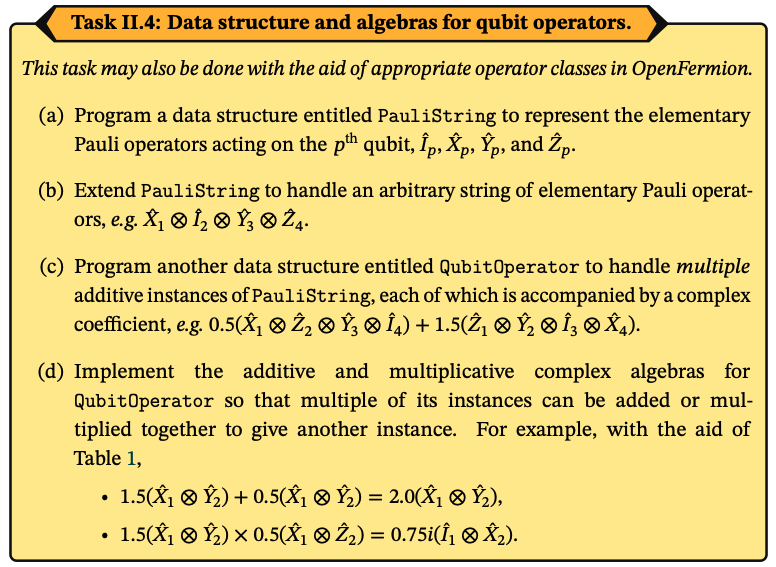

```python
Image('2_4.png')
```

First verify multiplication rules, leaving out identity since it is trivial. Do they agree with the table given in the laboratory manual [1]?

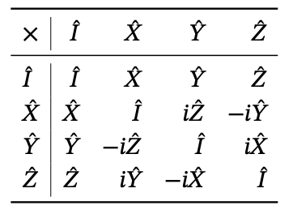

```python
Image('mult_table.png')
```

```python
X = np.array([[0, 1], [1, 0]], dtype=complex)
Y = np.array([[0, -1j], [1j, 0]], dtype=complex)
Z = np.array([[1, 0], [0, -1]], dtype=complex)

print("XX =",X@X)
print("\nXY =",X@Y)
print("\nXZ =",X@Z)
print("\nYX =",Y@X)
print("\nYY =",Y@Y)
print("\nYZ =",Y@Z)
print("\nZX =",Z@X)
print("\nZY =",Z@Y)
print("\nZZ =",Z@Z)
```

```
XX = [[1.+0.j 0.+0.j]
 [0.+0.j 1.+0.j]]

XY = [[0.+1.j 0.+0.j]
 [0.+0.j 0.-1.j]]

XZ = [[ 0.+0.j -1.+0.j]
 [ 1.+0.j  0.+0.j]]

YX = [[0.-1.j 0.+0.j]
 [0.+0.j 0.+1.j]]

YY = [[1.+0.j 0.+0.j]
 [0.+0.j 1.+0.j]]

YZ = [[0.+0.j 0.+1.j]
 [0.+1.j 0.+0.j]]

ZX = [[ 0.+0.j  1.+0.j]
 [-1.+0.j  0.+0.j]]

ZY = [[0.+0.j 0.-1.j]
 [0.-1.j 0.+0.j]]

ZZ = [[1.+0.j 0.+0.j]
 [0.+0.j 1.+0.j]]
```

As desired.

**(a)**

```python
class PauliString:
    def __init__(self, ops=()):  #ops like [(1,"X"), (2,"I"),...]
        self._qop = ofQubitOperator(())  #identity
#(b)
        for p, op in ops:
            if op != "I":
                self._qop *= ofQubitOperator(((p, op),), 1.0)

    def __str__(self):
        return str(self._qop)

    def to_openfermion(self):
        return self._qop
```

Note that an error message is printed if a string other than $I,X,Y$, or $Z$ is entered.

```python
print(PauliString([(1,"X"),(2,"I"),(3,"Y"),(4,"Z")]))
```

```
1.0 [X1 Y3 Z4]
```

**(c)**

```python
class QubitOperator:
    def __init__(self, terms=()):
        self._qop = ofQubitOperator()#zero operator
        for coeff, ps in terms:
            self._qop += coeff * ps.to_openfermion()

    def to_openfermion(self):
        return self._qop

    def __str__(self):
        return str(self._qop)
#(d)
    def __add__(self, other):
        out = QubitOperator()
        out._qop = self._qop + other._qop
        return out

    def __mul__(self, other):
        out = QubitOperator()
        out._qop = self._qop * other._qop
        return out

    def __rmul__(self, other):
        out = QubitOperator()
        out._qop = other * self._qop
        return out
```

```python
psA = PauliString([(1,"X"), (2,"Y")])
psB = PauliString([(1,"X"), (2,"Z")])
a=QubitOperator([(1.5,psA),(0.5,psA)])
b=QubitOperator([(1.5,psA)])
c=QubitOperator([(0.5,psB)])
print(a)
print(b*c)
```

```
2.0 [X1 Y2]
0.75j [X2]
```

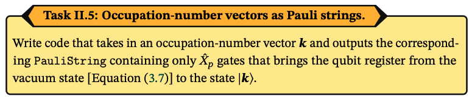

```python
Image('2_5.png')
```

```python
def occupation_to_paulistring(k):
    ops = [(p, "X") for p, occ in enumerate(k) if occ]
    return PauliString(ops)

ps = occupation_to_paulistring(k1)
print(ps)
```

```
1.0 [X0 X2]
```

#### Jordan-Wigner transformation

In the occupation basis, each spin-orbital $p$ is mapped to a qubit with $|1\rangle$ denoting occupied and $|0\rangle$ denoting vacant.

To represent fermionic creation and annihilation operators by qubit operators that act identically on occupation-number states, define the Jordan-Wigner qubit operators $$ \hat q_p^\dagger=\left(\bigotimes_{q=0}^{p-1}\hat Z_q\right)\,\frac{\hat X_p-i\hat Y_p}{2}, \qquad \hat q_p=\left(\bigotimes_{q=0}^{p-1}\hat Z_q\right)\,\frac{\hat X_p+i\hat Y_p}{2}. $$ Then the mapping is $$ |\mathbf k\rangle \ \leftrightarrow\ |k_0k_1\cdots k_{M-1}\rangle,\qquad \hat a_p^\dagger \ \leftrightarrow\ \hat q_p^\dagger,\qquad \hat a_p \ \leftrightarrow\ \hat q_p, $$ so fermionic operators (and hence $\hat H$) can be converted into sums of Pauli strings acting on qubits [1].

Verifying that $\hat{a}^\dagger_p \leftrightarrow \hat{q}^\dagger_p$ and $\hat{a}_p \leftrightarrow \hat{q}_p$. Noting that for this example the first $q$ has index $1$, like in the manual.

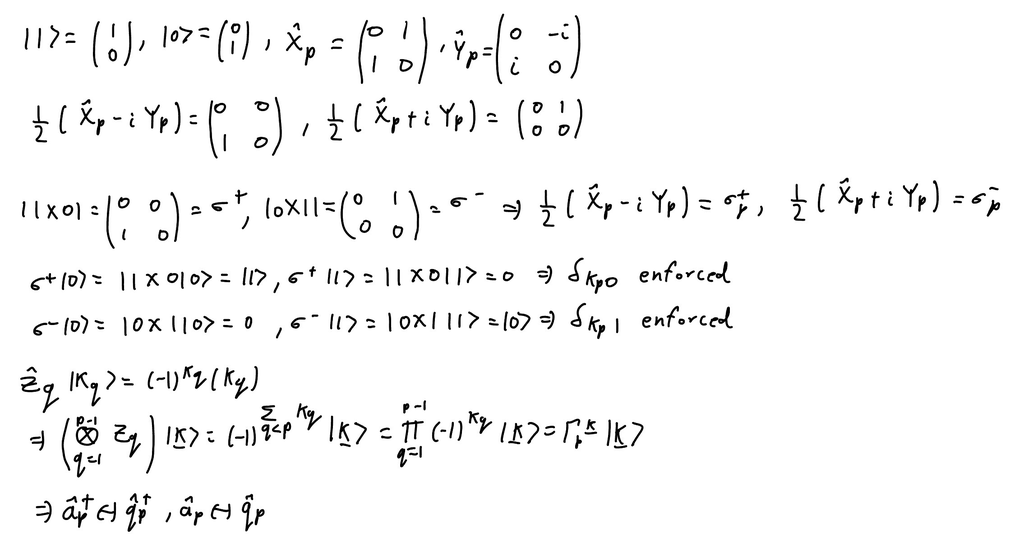

```python
Image('JW.jpg')
```

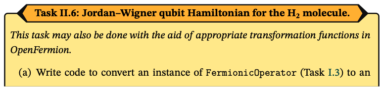

```python
Image('2_6a.png')
```

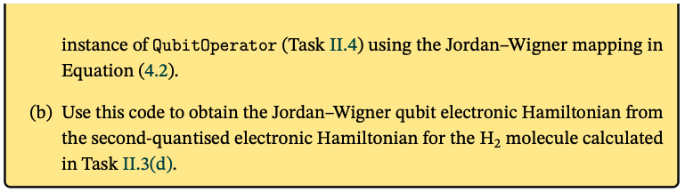

```python
Image('2_6b.png')
```

**(a)**

```python
# rough work for of_ferm.terms.items()
a=FermionicOperator.string([(1,1), (2,1), (3,0), (4,0)], 0.5).to_openfermion()
a.terms.items()
```

```
dict_items([(((1, 1), (2, 1), (3, 0), (4, 0)), (0.5+0j))])
```

```python
def jw_transform(ferm_op):
    of_ferm = ferm_op.to_openfermion()
    qop = ofQubitOperator()

    for term, coeff in of_ferm.terms.items():
        jw = ofQubitOperator((), 1.0)

        for p, ca in term:
            # Z string
            for q in range(p):
                jw *= ofQubitOperator(((q,"Z"),), 1.0)
            if ca == 1:
                #creation
                jw *= (0.5 * ofQubitOperator(((p,"X"),), 1.0) - 0.5j * ofQubitOperator(((p,"Y"),), 1.0))
            else:
                # annihilation
                jw *= (0.5 * ofQubitOperator(((p,"X"),), 1.0) + 0.5j * ofQubitOperator(((p,"Y"),), 1.0))

        qop += complex(coeff) * jw

    mapped = QubitOperator()
    mapped._qop = qop
    #map to QubitOperator class
    return mapped
```

**(b)**

```python
H_q = jw_transform(H)
print(H_q)
```

```
(-0.32760818967481076+0j) [] +
(-0.049197645871367546+0j) [X0 X1 Y2 Y3] +
(0.049197645871367546+0j) [X0 Y1 Y2 X3] +
(0.049197645871367546+0j) [Y0 X1 X2 Y3] +
(-0.049197645871367546+0j) [Y0 Y1 X2 X3] +
(0.13716572937099492+0j) [Z0] +
(0.1566006248823794+0j) [Z0 Z1] +
(0.10622904490856078+0j) [Z0 Z2] +
(0.15542669077992832+0j) [Z0 Z3] +
(0.13716572937099483+0j) [Z1] +
(0.15542669077992832+0j) [Z1 Z2] +
(0.10622904490856078+0j) [Z1 Z3] +
(-0.13036292057109045+0j) [Z2] +
(0.1632676867356434+0j) [Z2 Z3] +
(-0.13036292057109042+0j) [Z3]
```

Note that Pauli operators acting on different qubits commute (i.e. $\hat{X}_0 \hat{X}_1 \hat{Y}_2 \hat{Y}_3=\hat{Y}_2\hat{X}_1\hat{X}_0\hat{Y}_3$), so order doesn't matter. Pauli operators acting on the same qubit generally do not commute (i.e. $\hat{X}_p \hat{Y}_p = i \hat{Z}_p$ while $\hat{Y}_p \hat{X}_p = -i \hat{Z}_p$), so ordering matters when multiple Paulis act on the same qubit.

Compare against PySCF.

```python
atom = """
H 0 0 0
H 0 0 1
"""
mol = MolecularData(atom, "sto-3g", multiplicity=1)
mol = run_pyscf(mol)

H_ref = jordan_wigner(mol.get_molecular_hamiltonian())
print(H_ref)
```

```
-0.3276081896748101 [] +
-0.049197645871367546 [X0 X1 Y2 Y3] +
0.049197645871367546 [X0 Y1 Y2 X3] +
0.049197645871367546 [Y0 X1 X2 Y3] +
-0.049197645871367546 [Y0 Y1 X2 X3] +
0.13716572937099492 [Z0] +
0.15660062488237944 [Z0 Z1] +
0.10622904490856078 [Z0 Z2] +
0.15542669077992832 [Z0 Z3] +
0.13716572937099492 [Z1] +
0.15542669077992832 [Z1 Z2] +
0.10622904490856078 [Z1 Z3] +
-0.13036292057109033 [Z2] +
0.1632676867356434 [Z2 Z3] +
-0.13036292057109033 [Z3]
```

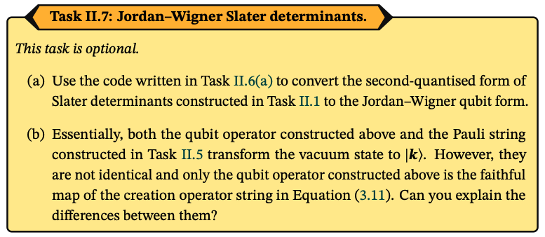

```python
Image('2_7.png')
```

**(a)**

```python
op = occupation_to_operator(k1)
print('For second-quantized k1 =',op.to_openfermion(),'the Jordan-Wigner qubit form is:',jw_transform(op))
```

```
For second-quantized k1 = (1+0j) [0^ 2^] the Jordan-Wigner qubit form is: (0.25+0j) [X0 Z1 X2] +
-0.25j [X0 Z1 Y2] +
-0.25j [Y0 Z1 X2] +
(-0.25+0j) [Y0 Z1 Y2]
```

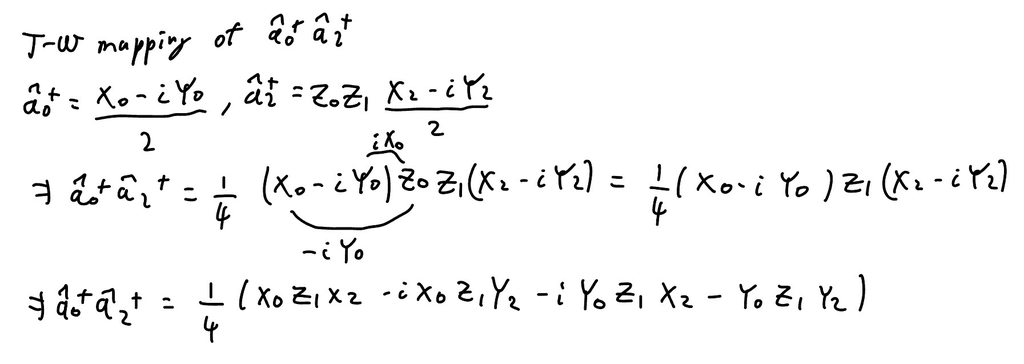

```python
Image('JWexample.jpg')
```

**(b)**

Jordan-Wigner mapping is the true operator map of $\prod_p (a_p^\dagger)^{k_p}$, including the parity string $\bigotimes_{q=0}^{p-1} \hat{Z}_q$ and the $(\hat{X}_p \mp i\hat{Y}_p)/2$ structure, so it expands into a sum of Pauli strings that preserves fermionic anticommutation.

The Pauli string $\hat{X}_0\hat{X}_2$ is a state preparation shortcut that flips $|000\rangle \to |101\rangle$. It does not enforce fermionic occupancy rules or anticommutation. For example $\hat{X}_0\hat{X}_2|011\rangle = |110\rangle$, while $\hat a_0^\dagger \hat a_2^\dagger|011\rangle = 0$ because creating on an already occupied mode gives zero.

## Module 2 Logbook

This laboratory extended the second quantisation formalism to the electronic Hamiltonian and introduced the Jordan-Wigner transformation, which maps fermionic creation and annihilation operators to Pauli operators on qubits. A comparison between simply applying $X$ operators and the full Jordan-Wigner mapping showed that while the simple method can reproduce the correct bitstring for some state preparations, it does not implement fermionic creation and annihilation operators.

The Jordan-Wigner mapping was implemented with the parity $Z$ string and the $(X\mp iY)/2$ structure, applied term by term to each fermionic string. Even though each elementary fermionic operator maps to only two Pauli terms, multiplying several of them together produces large strings.

The main computational consideration for PauliString and QubitOperator was to keep them as simple and general as possible. OpenFermion’s QubitOperator was used for the bookkeeping, combining like terms and keeping a consistent ordering. A thin wrapper was then added to provide addition and multiplication.

Correctness was checked using the same workflow the code is meant for. The elementary Pauli multiplication rules were verified directly by matrix multiplication of $X$, $Y$, and $Z$. Then, the PauliString and QubitOperator classes were tested on the specific addition and multiplication examples provided, confirming that identical Pauli strings combined correctly by coefficient addition and that multiplication produced the expected phase factors and Pauli products. The second quantised $H_2$ Hamiltonian constructed from the UHF Molecular Orbital transformation was compared against an OpenFermion reference Hamiltonian generated from PySCF output, and the term list agreed (up to numerical precision). Finally, the Jordan-Wigner Hamiltonian produced by the custom mapping was compared against OpenFermion's built in transform, and the resulting Pauli terms and coefficients matched.

# Part III

## Simulation Framework

#### Classical simulation of state-vectors

An $M$-qubit pure state in the computational basis can be stored classically as a length $2^M$ state-vector of complex amplitudes. For a product state $$ |\Psi_q\rangle=\bigotimes_{p=0}^{M-1}|\psi_p\rangle,\qquad |\psi_p\rangle=c_{p,0}|0_p\rangle+c_{p,1}|1_p\rangle,\quad |c_{p,0}|^2+|c_{p,1}|^2=1, $$ the corresponding state-vector entries are amplitudes for basis states $|i_0i_1\cdots i_{M-1}\rangle$: $$ V_{i_0i_1\cdots i_{M-1}}=\prod_{p=0}^{M-1} c_{p,i_p},\qquad i_p\in\{0,1\}, $$ and $|V_{i_0i_1\cdots i_{M-1}}|^2$ gives the associated frequency [1].

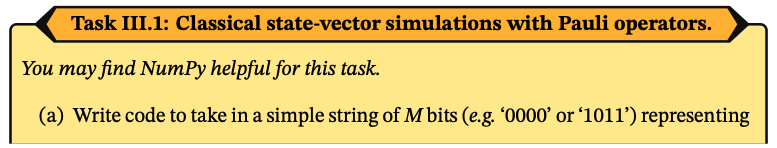

```python
Image('3_1a.png')
```

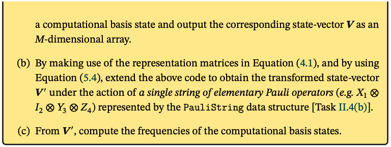

```python
Image('3_1b.png')
```

**(a)**

```python
def b_svtensor(bstr):
    bits = tuple(int(b) for b in bstr.strip())
    M = len(bits)
    V = np.zeros((2,) * M, dtype=complex)
    V[bits] = 1 #sets amplitude of bstr to 1
    return V
```

```python
V = b_svtensor("1011")
print("Shape of V:",V.shape)
print("V[1,0,1,1]:",V[1,0,1,1])
print("V:",V)
```

```
Shape of V: (2, 2, 2, 2)
V[1,0,1,1]: (1+0j)
V: [[[[0.+0.j 0.+0.j]
   [0.+0.j 0.+0.j]]

  [[0.+0.j 0.+0.j]
   [0.+0.j 0.+0.j]]]


 [[[0.+0.j 0.+0.j]
   [0.+0.j 1.+0.j]]

  [[0.+0.j 0.+0.j]
   [0.+0.j 0.+0.j]]]]
```

**(b)**

Note 3

If a $k$-qubit unitary $\hat U$ acts on selected qubits, the updated state-vector $V'$ is obtained by contracting $\hat U$ with $V$ over the acted-upon indices. $\Rightarrow V'_{\cdots i_{p-1}'ai_{p+1}' \cdots}=\sum_{b}V_{\cdots i_{p-1}bi_{p+1}\cdots}U_{ab}.$

Since the state-vector dimension scales as $2^M$, only small $M$ classical simulations are possible [1].

```python
pauli = {"I": np.eye(2, dtype=complex),"X": np.array([[0, 1], [1, 0]], dtype=complex),
         "Y": np.array([[0, -1j], [1j, 0]], dtype=complex),"Z": np.array([[1, 0], [0, -1]], dtype=complex)}

def apply_paulistring(V, ps):
    #V from b_svtensor
    qop = ps.to_openfermion()
    terms = list(qop.terms.items())

    term, coeff = terms[0]
    # term is e.g. ((p,'X'), (q,'Z'), ...)
    Vp = V * coeff
    for p, op in term:
        Vp = np.tensordot(pauli[op], Vp, axes=([1], [p])) #note 3
        Vp = np.moveaxis(Vp, 0, p) #tensordot inserts the new output index of the Pauli matrix as axis 0
    return Vp
```

**(c)**

```python
def frequencies(Vp):
    probs = np.abs(Vp)**2
    return probs
```

```python
V = b_svtensor("1011")
ps = PauliString([(0,"X"), (1,"I"), (2,"Y"), (3,"Z")])
#arbitrary

Vp = apply_paulistring(V, ps)
freq = frequencies(Vp)
print("V':",Vp)
print("\nFrequency:",freq)
print("\nSum of frequencies:",freq.sum())
print("V'[0,0,0,1]:",Vp[0,0,0,1])
```

```
V': [[[[0.+0.j 0.+1.j]
   [0.+0.j 0.+0.j]]

  [[0.+0.j 0.+0.j]
   [0.+0.j 0.+0.j]]]


 [[[0.+0.j 0.+0.j]
   [0.+0.j 0.+0.j]]

  [[0.+0.j 0.+0.j]
   [0.+0.j 0.+0.j]]]]

Frequency: [[[[0. 1.]
   [0. 0.]]

  [[0. 0.]
   [0. 0.]]]


 [[[0. 0.]
   [0. 0.]]

  [[0. 0.]
   [0. 0.]]]]

Sum of frequencies: 1.0
V'[0,0,0,1]: 1j
```

Try $X_0Z_0\otimes I_1\otimes Y_2\otimes Z_3 \otimes Z_4$.

```python
V = b_svtensor("10110")

ps = PauliString([(4,"Z")])
Vp = apply_paulistring(V, ps)

ps1 = PauliString([(4,"X"), (3,"I"), (2,"Y"), (1,"Z"),(0,"Z")])
Vp = apply_paulistring(Vp, ps1)
freq = frequencies(Vp)

print("V':",Vp)
print("\nFrequency:",freq)
print("\nSum of frequencies:",freq.sum())
print("V'[1,0,0,1,1]:",Vp[1,0,0,1,1])
```

```
V': [[[[[0.+0.j 0.+0.j]
    [0.+0.j 0.+0.j]]

   [[0.+0.j 0.+0.j]
    [0.+0.j 0.+0.j]]]


  [[[0.+0.j 0.+0.j]
    [0.+0.j 0.+0.j]]

   [[0.+0.j 0.+0.j]
    [0.+0.j 0.+0.j]]]]



 [[[[0.+0.j 0.+0.j]
    [0.+0.j 0.+1.j]]

   [[0.+0.j 0.+0.j]
    [0.+0.j 0.+0.j]]]


  [[[0.+0.j 0.+0.j]
    [0.+0.j 0.+0.j]]

   [[0.+0.j 0.+0.j]
    [0.+0.j 0.+0.j]]]]]

Frequency: [[[[[0. 0.]
    [0. 0.]]

   [[0. 0.]
    [0. 0.]]]


  [[[0. 0.]
    [0. 0.]]

   [[0. 0.]
    [0. 0.]]]]



 [[[[0. 0.]
    [0. 1.]]

   [[0. 0.]
    [0. 0.]]]


  [[[0. 0.]
    [0. 0.]]

   [[0. 0.]
    [0. 0.]]]]]

Sum of frequencies: 1.0
V'[1,0,0,1,1]: 1j
```

Now compare against Qiskit's classical state-vector simulators. Note that Qiskit uses the rightmost bit as qubit $0$ convention, which will be used for the remaining sections.

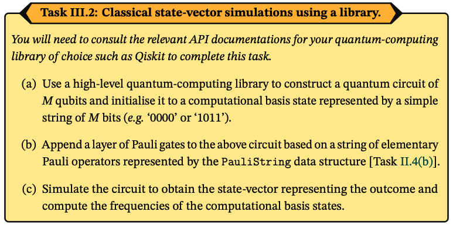

```python
Image('3_2.png')
```

```python
service = QiskitRuntimeService(name="oxford-chem")
```

```
management.get:WARNING:2026-03-09 10:30:35,457: Loading saved account: oxford-chem
```

**(a)**

```
'0000'
```

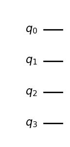

```python
qc0000 = QuantumCircuit(4)


print("'0000'")
qc0000.draw("mpl")
```

```
'1011'
```

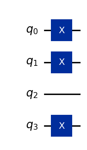

```python
qc1011 = QuantumCircuit(4)
qc1011.x(0)
qc1011.x(1)
qc1011.x(3)
print("'1011'")
qc1011.draw("mpl")
```

**(b)**

```python
def append_pauli(qc, ps):
    term = next(iter(ps.to_openfermion().terms)) #next gets first key from dict
    for p, op in term:
        if op == "X":
            qc.x(p)
        elif op == "Y":
            qc.y(p)
        elif op == "Z":
            qc.z(p)
    return qc
```

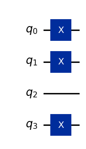

```python
qc = QuantumCircuit(4)

ps = PauliString([(0, "X"), (1, "X"), (3, "X")])

append_pauli(qc, ps)
qc.draw("mpl")
```

**(c)**

**Check agreement with III.1 (a)**

```python
sv = Statevector.from_instruction(qc)
print("Statevector :", sv.data)
probs = sv.probabilities_dict()
print("Probabilities :", probs)
```

```
Statevector : [0.+0.j 0.+0.j 0.+0.j 0.+0.j 0.+0.j 0.+0.j 0.+0.j 0.+0.j 0.+0.j 0.+0.j
 0.+0.j 1.+0.j 0.+0.j 0.+0.j 0.+0.j 0.+0.j]
Probabilities : {np.str_('1011'): np.float64(1.0)}
```

Statevector agrees with III.1 (a)

Comments are from IBM Quantum learning [6].

```python
backend = AerSimulator()

print(backend.name)
```

```
aer_simulator
```

```python
## Transpile
target = backend.target
pm = generate_preset_pass_manager(target=target, optimization_level=3)
qc_1=qc.copy()
qc_1.measure_all()
qc_isa = pm.run(qc_1)
```

```python
sampler = Sampler(mode=backend)
pubs = [qc_isa] # Primitive Unified Blocs, holds circuit
job = sampler.run(pubs, shots=1000) # repeats the circuit 1000 times
res = job.result()

counts = res[0].data.meas.get_counts()
```

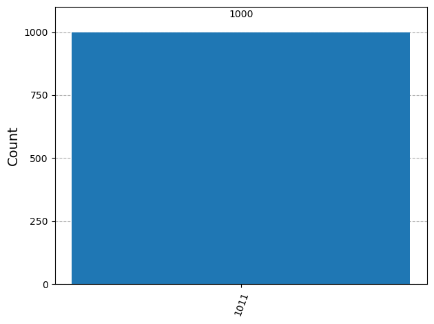

```python
## Analysis

plot_histogram(counts)
#plt.hist(counts)
```

Aer simulator gives expected result for III.1 (a)

**Check agreement with III.1(c)**

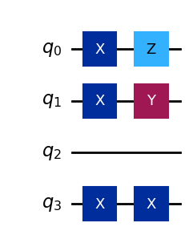

```python
ps1 = PauliString([(3,"X"), (2,"I"), (1,"Y"), (0,"Z")])
append_pauli(qc, ps1)
qc.draw("mpl")
```

```python
sv = Statevector.from_instruction(qc)
print("Statevector :", sv.data)
probs = sv.probabilities_dict()
print("Probabilities :", probs)
```

```
Statevector : [0.+0.j 0.+1.j 0.+0.j 0.+0.j 0.+0.j 0.+0.j 0.+0.j 0.+0.j 0.+0.j 0.+0.j
 0.+0.j 0.+0.j 0.+0.j 0.+0.j 0.+0.j 0.+0.j]
Probabilities : {np.str_('0001'): np.float64(1.0)}
```

Statevector agrees with III.1 (c)

```python
## Transpile
target = backend.target
pm = generate_preset_pass_manager(target=target, optimization_level=3)
qc_2=qc.copy()
qc_2.measure_all()
qc_isa = pm.run(qc_2)
```

```python
sampler = Sampler(mode=backend)
pubs = [qc_isa] # Primitive Unified Blocs, holds circuit
job = sampler.run(pubs, shots=1000) # repeats the circuit 1000 times
res = job.result()

counts = res[0].data.meas.get_counts()
```

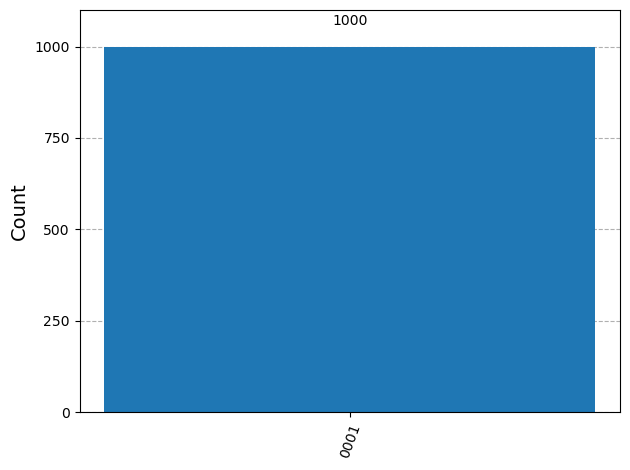

```python
## Analysis

plot_histogram(counts)
#plt.hist(counts)
```

Aer simulator gives expected result for III.1 (c)

**Check agreement with $X_0Z_0\otimes I_1\otimes Y_2\otimes Z_3 \otimes Z_4$.**

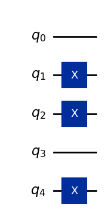

```python
qc = QuantumCircuit(5)

ps = PauliString([(1, "X"), (2, "X"), (4, "X")])

append_pauli(qc, ps)

qc.draw("mpl")
```

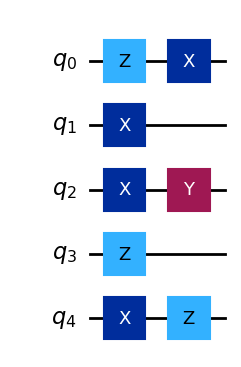

```python
ps2 = PauliString([(0,"Z")])
append_pauli(qc, ps2)
ps3 = PauliString([(0,"X"),(4,"Z"), (3,"Z"), (2,"Y"), (1,"I")]) #in little endian
append_pauli(qc, ps3)
qc.draw("mpl")
```

```python
sv = Statevector.from_instruction(qc)
print("Statevector :", sv.data)
probs = sv.probabilities_dict()
print("Probabilities :", probs)
```

```
Statevector : [0.+0.j 0.+0.j 0.+0.j 0.+0.j 0.+0.j 0.+0.j 0.+0.j 0.+0.j 0.+0.j 0.+0.j
 0.+0.j 0.+0.j 0.+0.j 0.+0.j 0.+0.j 0.+0.j 0.+0.j 0.+0.j 0.+0.j 0.+1.j
 0.+0.j 0.+0.j 0.+0.j 0.+0.j 0.+0.j 0.+0.j 0.+0.j 0.+0.j 0.+0.j 0.+0.j
 0.+0.j 0.+0.j]
Probabilities : {np.str_('10011'): np.float64(1.0)}
```

Statevector agrees.

```python
## Transpile
target = backend.target
pm = generate_preset_pass_manager(target=target, optimization_level=3)
qc_2=qc.copy()
qc_2.measure_all()
qc_isa = pm.run(qc_2)
```

```python
sampler = Sampler(mode=backend)
pubs = [qc_isa] # Primitive Unified Blocs, holds circuit
job = sampler.run(pubs, shots=1000) # repeats the circuit 1000 times
res = job.result()

counts = res[0].data.meas.get_counts()
```

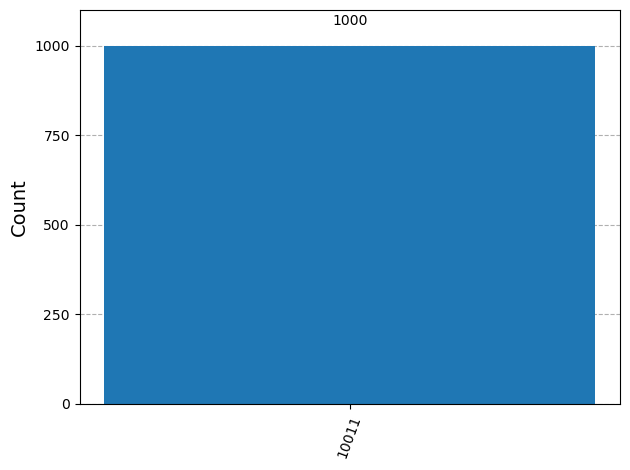

```python
## Analysis

plot_histogram(counts)
#plt.hist(counts)
```

Aer simulator gives expected result.